[O’Hara on GitHub](https://github.com/oharac)

# Calculate climate stressor sensitivities from IUCN impact scores

Compiled on Mon Apr 19 19:10:02 2021 by ohara

```r
knitr::opts_chunk$set(fig.width = 6, fig.height = 4, fig.path = 'figs/',
                      echo = TRUE, message = FALSE, warning = FALSE)

source('https://raw.githubusercontent.com/oharac/src/master/R/common.R')

source(here::here('common_fxns.R'))

library(tidytext) ### to help parse ngrams in the narratives
```

# 1 Summary

Stressor sensitivity is a very simplified version of stressor weights (see draft1 folder for complicated version). Here, we will simply note whether a given species is sensitive to a given stressor, using the IUCN impact weights (i.e. non-negligible impact score), ranked as 0-3 (no, low, medium, high impact) for later differentiation if necessary. For species with NA impact scores, we can imply sensitivity based on other fields, e.g. severity. This version of sensitivity is not related to the range of exposure, as the weight calculation was doing.

Sensitivity will denote whether a species range overlapping a stressor range constitutes an impact.

# 2 Methods

## 2.1 Set up stressor sensitivity dataframe

Using all listed threats and the threat-to-stressor lookup, and focusing on those species with valid maps (i.e. a csv file in `spp_rasts_mol_2019`), identify species with non-negligible impacts from impact score, and where impact is unknown, based on severity field. Here we are looking at climate threats. To differentiate between SST, SLR, OA, and possibly UV sensitivity (though UV not included in Halpern 2019), we will mine the species narratives for keywords, and use habitat information to locate the species in the water column.

In cases where a species is impacted by multiple threats that map to a single stressor (e.g. different mentions of SST in different threat categories) we summarize to the *maximum* score out of all listed. For example, a species suffers low impact from residential development (score = 3) but medium impact from commercial (score = 5), the direct human impact layer will be weighted as a 5 across the board.

In this step we will include all species including LC and DD. We will however limit to comprehensively assessed taxa.

| Code | Description | Potential strs |
| --- | --- | --- |
| 11 | Climate change & severe weather | NA |
| 11.1 | Habitat shifting & alteration | sst, slr, oa |
| 11.2 | Droughts | NA |
| 11.3 | Temperature extremes | sst, oa^*^ |
| 11.4 | Storms & flooding | NA |
| 11.5 | Other impacts | sst^*^, oa, slr |

* Note that ocean acidification effects are often described in narratives for species only classified with code 11.3, and sea surface temperature, ocean acidification, and sea level rise impacts are often described in narratives for species only classified with code 11.5.

```r
spp_marine <- read_csv(here('_data', sprintf('spp_marine_from_api_%s.csv', api_version)))

spp_maps <- read_csv(here('_data', sprintf('spp_marine_maps_%s.csv', api_version)))

spp_risk <- read_csv(here('_data', sprintf('iucn_risk_current_%s.csv', api_version))) %>%
  select(iucn_sid, cat_score)

spp_comp <- read_csv(here('_data', sprintf('iucn_comp_assessed_%s.csv', api_version)))

chi_lookup <- read_csv(here('_raw/iucn_threat_to_stressor_lookup.csv')) %>%
  mutate(stressor = str_split(stressor, ';')) %>%
  unnest(stressor) %>%
  filter(str_detect(stressor, '[a-z]')) %>%
  filter(category == 'climate')

spp_threats <- read_csv(file.path(dir_bd_anx, 'iucn/threats',
                               sprintf('iucn_spp_threats_%s.csv', api_version))) %>%
  left_join(chi_lookup, by = 'code') %>%
  filter(!is.na(code))

### Join the maps to the threats.
### * recategorize sensitivities based on impact score
### * if no impact score, categorize sensitivities based on severity
### * rather than filtering, set NA and past scores to 0
###   * this allows non-threatened species to remain in the mix
threats_to_marine <- spp_marine %>%
  left_join(spp_risk, by = 'iucn_sid') %>%
  left_join(spp_threats, by = 'iucn_sid') %>%
  ### code low-med-high sensitivity based on impact:
  mutate(sens = case_when(score_num %in% 0:2 ~ FALSE,     ### no/negligible impact
                          score_num > 2      ~ TRUE,      ### non-negligible impact
                          TRUE               ~ NA)) %>%   ### set all else to NA
  ### for NA impact, code sensitivity based on severity:
  mutate(sev = tolower(severity),
         sens = case_when(is.na(sens) & str_detect(sev, 'negligible|no decl') ~ FALSE,
                          is.na(sens) & str_detect(sev, 'very rapid decl')    ~ TRUE,
                          is.na(sens) & str_detect(sev, 'rapid decl')         ~ TRUE,
                          is.na(sens) & str_detect(sev, 'causing|slow, significant') ~ TRUE,
                          TRUE ~ sens)) %>%
  ### set past impacts and unresolved sensitivies to 0:
  mutate(sens = ifelse(timing == 'Past, Unlikely to Return', FALSE, sens),
         sens = ifelse(is.na(sens), FALSE, sens)) %>%
  filter(!is.na(code)) %>% ### drop code mismatches
  filter(!is.na(stressor)) %>% ### drop codes that don't match stressors
  select(iucn_sid, cat_score, sens,
         code, stressor, score_num) %>%
  distinct()

### sensitivity categories:
# [1] "Unknown"                          "Negligible declines"
# [3] NA                                 "No decline"
# [5] "Rapid Declines"                   "Slow, Significant Declines"
# [7] "Causing/Could cause fluctuations" "Very Rapid Declines"

write_csv(threats_to_marine, here('int/spp_threats_climate.csv'))
```

```r
n_comp <- spp_marine %>%
  filter(iucn_sid %in% spp_maps$iucn_sid) %>%
  filter(iucn_sid %in% spp_comp$iucn_sid) %>%
  .$iucn_sid %>% unique() %>% length()
n_threatened <- spp_risk %>%
  filter(iucn_sid %in% spp_maps$iucn_sid) %>%
  filter(iucn_sid %in% spp_comp$iucn_sid) %>%
  filter(!is.na(cat_score) & !cat_score %in% c(0, 1)) %>%
  .$iucn_sid %>% unique() %>% length()

spp_stressed <- threats_to_marine %>%
  filter(iucn_sid %in% spp_maps$iucn_sid) %>%
  filter(iucn_sid %in% spp_comp$iucn_sid) %>%
  filter(!is.na(cat_score) & !cat_score %in% c(0, 1)) %>%
  filter(sens)

n_stressed <- spp_stressed %>%
  .$iucn_sid %>% unique() %>% length()
```

Out of the list of 6543 marine species with maps, 1271 are neither Least Concern nor Data Deficient.

The resulting number of threatened spp (including Near Threatened) with sensitivity to at least one **climate** stressor is: 545.

NOTE: These numbers may include a small handful of spp with effectively zero ocean range, which will not show up in maps, will not affect calculations, etc. These can be found from the impacted area dataframe.

## 2.2 Identify species habitat location (shallow vs. deep)

For fishing stressors, we differentiated between demersal and pelagic to predict likely impacts from different gear types. Here for climate impacts we examine shallow vs. deep species to help parse potential sensitivity to sea surface temperature and UV exposure, and species who rely on intertidal and shore to parse sensitivity to sea level rise.

- For SST: Shallow habitats include all neritic (9.X), epipelagic (10.1), marine intertidal (12.X), and marine coastal/supratidal (13.X).
- For SLR: Shoreline habitats include marine intertidal (12.X) and coastal/supratidal (13.X)
  - consider perhaps reef, seagrass, and estuary habitats (9.8, 9.9, 9.10 respectively). These are not currently included.

```r
spp_shallow_shore <- read_csv(file.path(dir_bd_anx, 'iucn',
                                sprintf('spp_habs_from_api_%s.csv', api_version)),
                     col_types = cols('iucn_sid' = 'i',
                                      'code' = 'c')) %>%
  select(iucn_sid, code, habitat, suitability) %>%
  distinct() %>%
  mutate(code_main = as.integer(str_replace_all(code, '\\..*', ''))) %>%
  filter(code_main %in% 9:13) %>% ### limit to marine spp
  mutate(shallow   = code_main %in% c(9, 12, 13) | code == '10.1',
         shoreline = code_main %in% c(12, 13)) %>%
  group_by(iucn_sid) %>%
  summarize(shallow = any(shallow),
            shoreline = any(shoreline)) %>%
  ungroup()

write_csv(spp_shallow_shore, here('int/spp_shallow_shore.csv'))
```

## 2.3 Check for climate instances in narratives

### 2.3.1 identify keywords for sea surface temperature

Examine trigrams from the narratives that include ‘temp’ or ‘sst’. Limit to the “threats” dimension since temperature may show up in “habitat” or other dimensions more innocuously.

```r
spp_narr_file <- file.path(dir_bd_anx, 'iucn',
                           sprintf('spp_narr_from_api_%s.csv', api_version))

spp_narrs <- read_csv(spp_narr_file,
                      col_types = cols(.default = 'c', iucn_sid = 'i')) %>%
  select(iucn_sid:usetrade) %>%
  gather(dimension, text, -iucn_sid) %>%
  ### remove HTML tags since they seem to affect the unnesting of sentences
  mutate(text = str_replace_all(text, '<.*?>', ' '))

### set up some stop words.  The stop_words df is a bit large and slow
### to search over... also doesn't drop numbers
cut_words <- data.frame(
    word = c('a', 'and', 'or', 'in', 'on', 'of', 'by',
             'to', 'but', 'the', 'from',
             '[0-9,;\\.]+')
  ) %>%
  mutate(combo = paste0('^', word, ' | ', word, '$')) %>%
    ### e.g. not "and trawl" or "trawling and"
  summarize(to_cut = paste0(combo, collapse = '|'))
```

```r
sst_search_string <- 'temperature|sst'

sst_text_df <- spp_narrs %>%
  filter(dimension == 'threats') %>%
  unnest_tokens(output = sentence, input = text,
                token = 'sentences', drop = FALSE) %>%
  ### prefilter to dramatically speed up the trigrams...
  filter(str_detect(tolower(sentence), sst_search_string)) %>%
  # group_by(iucn_sid, dimension) %>%
  unnest_tokens(output = trigram, input = sentence,
                token = 'ngrams', n = 3, drop = FALSE) %>%
  filter(str_detect(trigram, sst_search_string))


sst_trigram_df <- sst_text_df %>%
  select(-text, -iucn_sid) %>%
  filter(!str_detect(trigram, cut_words$to_cut)) %>%
  group_by(trigram) %>%
  summarize(instances = n()) %>%
  ungroup() %>%
  arrange(desc(instances)) %>%
  filter(instances > 1)

DT::datatable(sst_trigram_df)
```

|  | trigram | instances |
| --- | --- | --- |
| 1 | temperature extremes leading | 847 |
| 2 | sea surface temperatures | 841 |
| 3 | particular temperature extremes | 834 |
| 4 | increased ocean temperatures | 773 |
| 5 | ocean temperatures willis | 772 |
| 6 | temperatures willis et | 772 |
| 7 | ocean in temperatures | 77 |
| 8 | sea surface temperature | 50 |
| 9 | temperatures and ocean | 19 |
| 10 | increasing sand temperatures | 18 |

[output cut: 97 more lines]

Some frequent word combos:

- sea surface temperature
- increased (ocean/water)? temperature, increasing (water/sea)? temperature
- high (sea)? temperature
- temperature extreme, extreme temperature events, extreme elevated temperature
- temperatures willis (particularly for corals)
  - based on “Increased coral disease levels on the GBR were correlated with increased ocean temperatures (Willis et al. 2007) supporting the prediction that disease levels will be increasing with higher sea surface temperatures”
- caution to avoid sand or air temperature combinations!

### 2.3.2 identify keywords for sea ice loss

A number of mammals and sea birds are sensitive to sea ice loss, dependent on the ice for reproduction and pupping, haul outs, and protection. Here examine the full suite of spp to see if other taxa have sea ice dependency (and to avoid it if indirect).

```r
ice_search_string <- 'sea ice'

ice_text_df <- spp_narrs %>%
  filter(dimension == 'threats') %>%
  unnest_tokens(output = sentence, input = text,
                token = 'sentences', drop = FALSE) %>%
  ### prefilter to dramatically speed up the trigrams...
  filter(str_detect(tolower(sentence), ice_search_string)) %>%
  # group_by(iucn_sid, dimension) %>%
  unnest_tokens(output = trigram, input = sentence,
                token = 'ngrams', n = 3, drop = FALSE) %>%
  filter(str_detect(trigram, ice_search_string))


ice_trigram_df <- ice_text_df %>%
  filter(!str_detect(trigram, cut_words$to_cut)) %>%
  group_by(trigram) %>%
  summarize(instances = n()) %>%
  ungroup() %>%
  arrange(desc(instances)) %>%
  filter(instances > 1)

DT::datatable(ice_trigram_df)
```

|  | trigram | instances |
| --- | --- | --- |
| 1 | sea ice cover | 18 |
| 2 | arctic sea ice | 7 |
| 3 | sea ice has | 7 |
| 4 | sea ice for | 6 |
| 5 | sea ice extent | 5 |
| 6 | sea ice is | 5 |
| 7 | sea ice loss | 5 |
| 8 | antarctic sea ice | 4 |
| 9 | declining sea ice | 4 |
| 10 | sea ice could | 4 |

[output cut: 20 more lines]

Inspecting the results, `sea ice` on its own appears to capture legitimate threats.

### 2.3.3 identify keywords for ENSO and global warming

Many shallow water spp e.g. blennies and wrasses indicate a threat from water temperatures/oceanographic changes due to ENSO and global warming. Many (but not all) use similar phrasing:

- “Given this species’ restricted distribution and shallow water habitat, oceanographic environmental changes, such as those associated with future ENSO events, may have detrimental effects on the survival of this species.”
- “Given this species’ potentially restricted distribution and shallow water habitat, localized stochastic events, including future oceanographic environmental changes such as ENSO and global warming, may have detrimental effects on marine ecosystems and the survival of these shallow water regional endemic species.”

```r
enso_search_string <- '(^|[^a-z])enso($|[^a-z])|global warming'
  ### the regex keeps from 'enso' cueing on 'Tittensor' e.g.

enso_text_df <- spp_narrs %>%
  filter(dimension == 'threats') %>%
  unnest_tokens(output = sentence, input = text,
                token = 'sentences', drop = FALSE) %>%
  ### prefilter to dramatically speed up the trigrams...
  filter(str_detect(tolower(sentence), enso_search_string)) %>%
  # group_by(iucn_sid, dimension) %>%
  unnest_tokens(output = trigram, input = sentence,
                token = 'ngrams', n = 3, drop = FALSE) %>%
  filter(str_detect(trigram, enso_search_string))


enso_trigram_df <- enso_text_df %>%
  filter(!str_detect(trigram, cut_words$to_cut)) %>%
  group_by(trigram) %>%
  summarize(instances = n()) %>%
  ungroup() %>%
  arrange(desc(instances)) %>%
  filter(instances > 1)

DT::datatable(enso_trigram_df)
```

|  | trigram | instances |
| --- | --- | --- |
| 1 | severity of enso | 847 |
| 2 | along with enso | 77 |
| 3 | future enso events | 76 |
| 4 | strong enso events | 76 |
| 5 | after strong enso | 75 |
| 6 | duration of enso | 75 |
| 7 | enso events may | 75 |
| 8 | enso events that | 74 |
| 9 | with future enso | 72 |
| 10 | with enso disturbances | 68 |

[output cut: 41 more lines]

Inspection of the text indicates that `enso` and `global warming` both capture legitimate instances of threats.

### 2.3.4 identify keywords for ocean acidification

Examine trigrams for instances of “ocean acid”.

```r
oa_search_string <- 'ocean acidification|ocean acidity'
### 1077 caught by 'acid' alone, 1055 caught by 'ocean acid',
### 1053 caught by 'ocean acidification'
### dropped instances reference domoic acid or lead acid batteries.

oa_text_df <- spp_narrs %>%
  filter(dimension == 'threats') %>%
  unnest_tokens(output = sentence, input = text,
                token = 'sentences', drop = FALSE) %>%
  ### prefilter to dramatically speed up the trigrams...
  filter(str_detect(tolower(sentence), oa_search_string)) %>%
  # group_by(iucn_sid, dimension) %>%
  unnest_tokens(output = trigram, input = sentence,
                token = 'ngrams', n = 3, drop = FALSE) %>%
  filter(str_detect(trigram, oa_search_string))

oa_trigram_df <- oa_text_df %>%
  select(-text, -iucn_sid) %>%
  filter(!str_detect(trigram, cut_words$to_cut)) %>%
  group_by(trigram) %>%
  summarize(instances = n()) %>%
  ungroup() %>%
  arrange(desc(instances)) %>%
  filter(instances > 1)

DT::datatable(oa_trigram_df)
```

|  | trigram | instances |
| --- | --- | --- |
| 1 | ocean acidification place | 789 |
| 2 | ocean acidification caused | 118 |
| 3 | ocean acidification bruno | 21 |
| 4 | ocean acidification may | 9 |
| 5 | change ocean acidification | 8 |
| 6 | as ocean acidification | 7 |
| 7 | fishing ocean acidification | 6 |
| 8 | trawling ocean acidification | 6 |
| 9 | including ocean acidification | 4 |
| 10 | ocean acidification oil | 3 |

[output cut: 11 more lines]

It appears that “ocean acid” on its own is a decent search string to identify ocean acidification threats.

### 2.3.5 identify keywords for sea level rise

Examine tetragrams for instances of “sea level rise” or similar.

```r
slr_search_string <- 'sea level'
### 1077 caught by 'acid' alone, 1055 caught by 'ocean acid',
### 1053 caught by 'ocean acidification'
### dropped instances reference domoic acid or lead acid batteries.

slr_text_df <- spp_narrs %>%
  filter(dimension == 'threats') %>%
  unnest_tokens(output = sentence, input = text,
                token = 'sentences', drop = FALSE) %>%
  ### prefilter to dramatically speed up the trigrams...
  filter(str_detect(tolower(sentence), slr_search_string)) %>%
  # group_by(iucn_sid, dimension) %>%
  unnest_tokens(output = tetragram, input = sentence,
                token = 'ngrams', n = 4, drop = FALSE) %>%
  filter(str_detect(tetragram, slr_search_string))
### n_ids(slr_text_df)
### no hits on 'slr'; 134 hits with just 'sea level'; 65 with 'sea level rise

slr_tetragram_df <- slr_text_df %>%
  select(-text, -iucn_sid) %>%
  filter(!str_detect(tetragram, cut_words$to_cut)) %>%
  group_by(tetragram) %>%
  summarize(instances = n()) %>%
  ungroup() %>%
  arrange(desc(instances)) %>%
  filter(instances > 1)

DT::datatable(slr_tetragram_df)
```

|  | tetragram | instances |
| --- | --- | --- |
| 1 | sea level and high | 64 |
| 2 | within mean sea level | 64 |
| 3 | ratios sea level rise | 18 |
| 4 | sea level rise storm | 18 |
| 5 | sex ratios sea level | 18 |
| 6 | sea level rise is | 13 |
| 7 | change especially sea level | 7 |
| 8 | especially sea level rise | 7 |
| 9 | if sea level changes | 7 |
| 10 | rising sea levels associated | 7 |

[output cut: 15 more lines]

Some potential matches:

- sea level rise/rising
- changing/rising sea levels
- sea level change/changing

## 2.4 Parse threats to count by climate stressor type

Using the above analyses, set up keywords to map species sensitivities to the various climate stressors.

```r
### set up search terms for sea level rise:
slr_keywords <- c('sea level ris', 'changing sea level', 'rising sea level', 'sea level chang') %>%
  paste(collapse = '|')

### set up search terms for ocean acidification:
oa_keywords <- 'ocean acidifi'

### set up search terms for sea surface temperature:
sst_keywords <- c('sea surface temper',
                  'increas[a-z]+ (ocean|water|sea)? ?temper',
                  'high sea temper',
                  'temper[a-z]+ extreme',
                  'extreme (elevated )?temper',
                  'climate change',
                  'el ni[nñ]o', ### the ñ is not working right...
                  '(^|[^a-z])enso($|[^a-z])',
                  'sea ice',
                  'global warming',
                  'temper[a-z]+ willis') %>%
  paste0(collapse = '|')

cc_keywords <- paste(slr_keywords, oa_keywords, sst_keywords, sep = '|')
```

```r
cc_narr_df <- spp_narrs %>%
  filter(dimension %in% c('threats', 'rationale')) %>%
  tidytext::unnest_tokens(input = text, output = sentence,
                          token = 'sentences', drop = TRUE) %>%
  filter(str_detect(sentence, cc_keywords)) %>%
  mutate(oa_count  = str_count(sentence, oa_keywords),
         slr_count = str_count(sentence, slr_keywords),
         sst_count = str_count(sentence, sst_keywords))

cc_narr_tidy <- cc_narr_df %>%
  gather(stressor, count, ends_with('count')) %>%
  mutate(stressor = str_replace_all(stressor, '_count', '')) %>%
  group_by(iucn_sid, stressor) %>%
  summarize(count = sum(count))

# x <- cc_narr_tidy %>%
#   filter(stressor == 'oa' & count > 0)
### 1060 OA spp still here

write_csv(cc_narr_tidy, here('int/cc_narr_tidy.csv'))
```

## 2.5 Combine stressors with species IDs and habitats

Note that here we filter out occurrences of:

- species whose narrative suggests sensitivity to sea surface temperature but whose habitat does not include surface waters (<200m)
- species whose narrative suggests sensitivity to sea level rise but whose habitat does not include shoreline habitats.

```r
cc_narr_tidy          <- read_csv(here('int/cc_narr_tidy.csv'))
spp_shallow_shore     <- read_csv(here('int/spp_shallow_shore.csv'))
spp_threats_from_iucn <- read_csv(here('int/spp_threats_climate.csv'))

### identify all the unique climate stressors... drop 'uv' for now
# stressors <- spp_threats_from_iucn$stressor %>% unique()
stressors <- c('sst', 'slr', 'oa')

### join stressors from narratives to impact scores; filter out
### stressors that don't match with habitats.
cc_sens_df <- cc_narr_tidy %>%
  left_join(spp_shallow_shore, by = 'iucn_sid') %>%
  left_join(spp_threats_from_iucn, by = c('iucn_sid', 'stressor')) %>%
  filter(!(stressor == 'sst' & shallow == FALSE)) %>%
  filter(!(stressor == 'slr' & shoreline == FALSE))
### 866 spp sensitive to SST without regard to habitat; 865 after filter
### 75 spp sensitive to SLR without regard to habitat; 74 after filter.
### only 10 spp sensitive to ocean acidification - that does not seem right!
### Check that in the next code chunk.

### Summarize sensitivity to each stressor as any non-zero counts
### within that stressor category.  Complete the list so all stressors
### show up for all species, leaving NAs for those added via complete().
cc_sens_summary <- cc_sens_df %>%
  group_by(iucn_sid, stressor, code, score_num) %>%
  filter(!is.na(sens)) %>%
  summarize(sens = sum(count * sens) > 0) %>%
  group_by(iucn_sid) %>%
  complete(stressor = stressors) %>%
  ungroup() %>%
  mutate(score_num = ifelse(score_num >= 3 & !sens, NA, score_num))

write_csv(cc_sens_summary,
          here('int', sprintf('spp_sens_climate_%s.csv', api_version)))
```

```r
cc_oa_df <- cc_sens_df %>%
  filter(stressor == 'oa' & count > 0) %>%
  left_join(spp_to_include, by = c('iucn_sid', 'cat_score'))

corals <- spp_to_include %>%
  filter(str_detect(tolower(dbf_file), 'coral'))
# table(corals$cat_score)
#   0 0.2 0.4 0.6 0.8
# 298 175 201  27   5

coral_threats <- corals %>%
  select(iucn_sid, sciname, cat_score, threats) %>%
  distinct() %>%
  left_join(spp_threats, by = 'iucn_sid') %>%
  filter(score_num >= 3) %>%
  mutate(code_num = str_extract(code, '[0-9]+\\.') %>% as.integer()) %>%
  arrange(desc(code_num), desc(code)) %>%
  mutate(txt = paste0(code, ': ', title),
         txt = str_replace(txt, ' \\(.+\\)', ''),
         txt = fct_inorder(txt)) %>%
  select(iucn_sid, txt) %>%
  distinct() %>%
  group_by(txt) %>%
  summarize(n_spp_impacted = n()) %>%
  ungroup()

ggplot(coral_threats, aes(x = txt, y = n_spp_impacted)) +
  ggtheme_plot() +
  geom_col() +
  labs(x = 'Threat code', y = 'Number of spp impacted') +
  coord_flip()
```

## 2.6 Check the number of spp sensitive to different types…

```r
spp_sens <- cc_sens_summary %>%
  filter(iucn_sid %in% spp_maps$iucn_sid) %>%
  filter(iucn_sid %in% spp_comp$iucn_sid) %>%
  left_join(spp_risk, by = 'iucn_sid') %>%
  filter(!is.na(cat_score) & !cat_score %in% c(0, 1)) %>%
  filter(sens)

n_spp_sens <- spp_sens %>%
  .$iucn_sid %>%
  unique() %>%
  length()

drop_check_all <- spp_marine %>%
  filter(iucn_sid %in% spp_stressed$iucn_sid) %>%
  filter(!iucn_sid %in% spp_sens$iucn_sid) %>%
  left_join(spp_narrs, by = 'iucn_sid') %>%
  left_join(spp_maps, by = 'iucn_sid') %>%
  # left_join(spp_comp %>% select(-sciname), by = 'iucn_sid') %>%
  select(iucn_sid, sciname, dimension, text) %>%
  distinct()

drop_check <- drop_check_all %>%
  filter(dimension %in% c('rationale',
                          'threats')) %>%
  ### prefilter to dramatically speed up the unnest_tokens...
  # filter(str_detect(tolower(text), 'climate|temp|acid|el ni.o')) %>%
  unnest_tokens(output = sentence, input = text,
                token = 'sentences', drop = TRUE) %>%
  filter(str_detect(sentence, 'climate|temperature|acid|el ni.o|sea level|warming|sea ice'))
```

According to this analysis so far, there are 532 distinct threatened species (with maps, comprehensively assessed, etc) affected by various climate stressors. Note that 545 species are listed as threatened therefore a few are not being captured via specific mentions of climate impacts. Some may be indirect (e.g. food web interactions) or not climate related at all. See here for a sample of some that mention climate search terms but do not seem to indicate direct impacts:

|  | iucn_sid | sciname | dimension | sentence |
| --- | --- | --- | --- | --- |
| 1 | 2477 | Balaenoptera musculus | threats | the main food of antarctic blue whales, euphausia superba and e. crystallorophias , are predicted to decline during the 21 st century due both to reduced ocean productivity associated with warming (pi… |
| 2 | 165717 | Chaetodon rainfordi | threats | relies on live coral for food and recruitment, and has declined significantly following climate-induced coral depletion on the great barrier reef (pratchett&amp;#160; et al. |
| 3 | 195409 | Epinephelus itajara | threats | multiple cohorts were affected by a cold temperature event in 2010, which caused a die-off of juveniles in the everglades national park, florida (hallac et al . |
| 4 | 22697782 | Eudyptes robustus | threats | however, other members of the genus in the region have undergone considerable long-term declines ( e. sclateri , e. chrysocome ), perhaps due to oceanic warming and the associated change in distributi… |
| 5 | 22697789 | Eudyptes sclateri | threats | the absence of introduced terrestrial predators disrupting penguin populations on the mainland points towards sea-based issues, which most likely consist of changes in marine productivity due to ocean… |
| 6 | 22697810 | Spheniscus demersus | threats | western cape populations declined by 69% between 2001-2009, considered at least partly due to this climate-induced shift in fish stocks. |

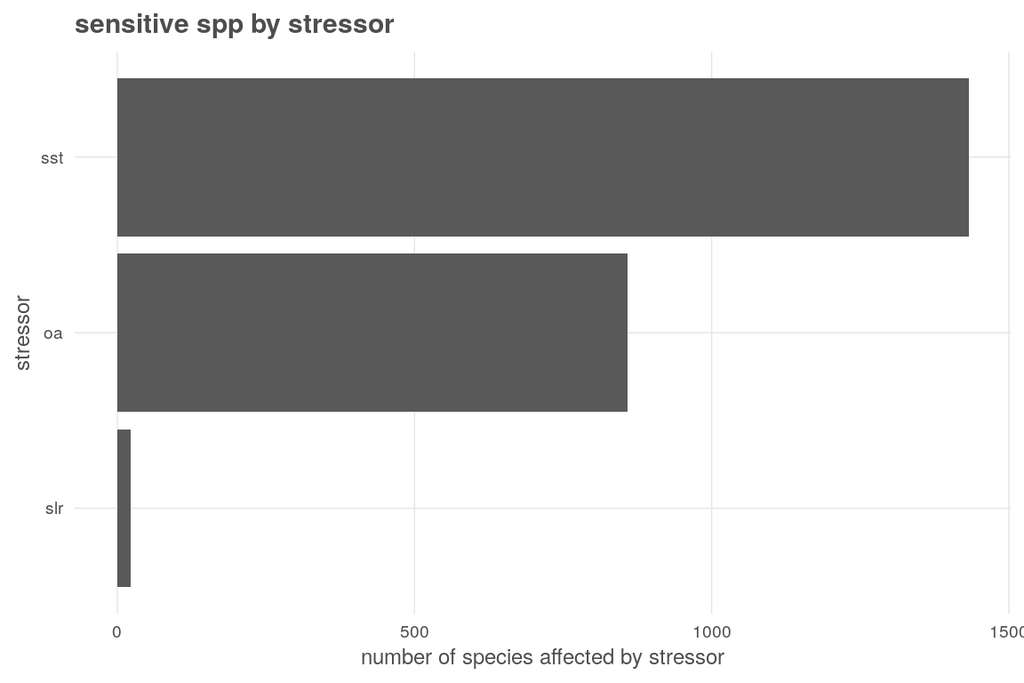

```r
spp_per_stressor <- cc_sens_summary %>%
  filter(sens) %>%
  count(stressor) %>%
  arrange(n) %>%
  mutate(stressor = fct_inorder(stressor))
ggplot(spp_per_stressor, aes(x = stressor, y = n)) +
  ggtheme_plot() +
  geom_col() +
  coord_flip() +
  labs(title = 'sensitive spp by stressor',
       y = 'number of species affected by stressor')
```

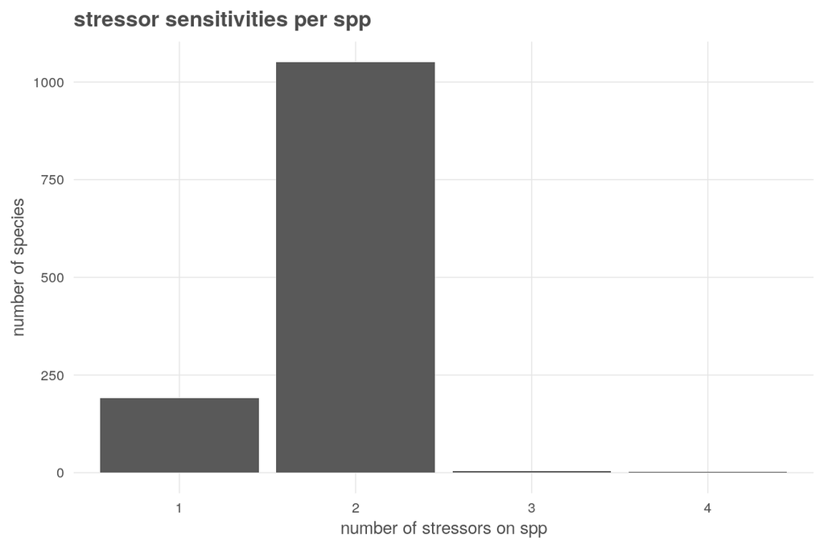

```r
stressor_per_spp <- cc_sens_summary %>%
  filter(sens) %>%
  count(iucn_sid) %>%
  mutate(n_txt = as.character(n))

ggplot(stressor_per_spp, aes(x = n_txt)) +
  ggtheme_plot() +
  geom_bar() +
  labs(title = 'stressor sensitivities per spp',
       x = 'number of stressors on spp',
       y = 'number of species')
```

Most species impacted by climate are impacted by two stressors (generally SST and OA).

## 2.7 Check for species listed as a threat but not otherwise captured

```r
threats  <- read_csv(here('int/spp_threats_climate.csv')) %>%
  rename(thr_sens = sens) %>%
  mutate(thr_listed = TRUE)
# iucn_sid; cat_score; code; stressor; thr_sens; thr_listed

cc_sum <- read_csv(here('int', sprintf('spp_sens_climate_%s.csv', api_version))) %>%
  rename(cc_sens = sens)
# iucn_sid; stressor; code; gear_sens

spp_comp <- read_csv(here('_data', sprintf('iucn_comp_assessed_%s.csv', api_version)))

tmp <- threats %>%
  left_join(cc_sum, by = c('iucn_sid', 'stressor', 'code')) %>%
  group_by(iucn_sid, code) %>%
  summarize(n_sens = sum(thr_sens),
            n_stressor = sum(cc_sens, na.rm = TRUE)) %>%
  ungroup()

tmp_nomatch <- tmp %>%
  filter(n_sens >= 1 & n_stressor == 0) %>%
  group_by(iucn_sid) %>%
  summarize(codes = paste(code, collapse = ', ')) %>%
  left_join(spp_comp, by = 'iucn_sid') %>%
  filter(!is.na(assess_gp)) %>%
  filter(assess_gp != 'sturgeons')

table(tmp_nomatch$assess_gp)
```

```
##
##               angelfishes                     birds                  blennies
##                         1                        13                         2
##          butterfly_fishes              clupeiformes crocodiles_and_alligators
##                         6                         1                         1
##                  groupers                   mammals              pufferfishes
##                         6                         9                         6
```

```r
DT::datatable(tmp_nomatch)
```

|  | iucn_sid | codes | sciname | assess_gp |
| --- | --- | --- | --- | --- |
| 1 | 2055 | 11.1 | Arctocephalus australis | mammals |
| 2 | 2477 | 11.1 | Balaenoptera musculus | mammals |
| 3 | 8239 | 11.1 | Eumetopias jubatus | mammals |
| 4 | 9660 | 11.1 | Halichoerus grypus | mammals |
| 5 | 13653 | 11.1 | Monachus monachus | mammals |
| 6 | 22104 | 11.1 | Trichechus senegalensis | mammals |
| 7 | 39774 | 11.1 | Cromileptes altivelis | groupers |
| 8 | 132751 | 11.1 | Epinephelus coeruleopunctatus | groupers |
| 9 | 132763 | 11.1 | Epinephelus corallicola | groupers |
| 10 | 132766 | 11.1 | Epinephelus macrospilos | groupers |

[output cut: 35 more lines]

Note that each of these is listed as being threatened by climate pressures, but no categorization of stressor was found. That may be legitimate - category 11 includes general impacts from habitat loss so clearly may be affected by other impacts other than SLR, SST, and OA. Inspect each of these to better understand/inform more keywords. (Before adding checks for enso, global warming, and sea ice there were 95 spp with a category 11 threat but no match. Of these, about half seemed legitimate instances of climate threats).